# AKSSF Temperature Data Summary

Document last updated 2022-02-22 22:42:45 by Rebecca Shaftel (rsshaftel@alaska.edu).

This report summarizes the new thermal sensitivity results for team meeting on February 22, 2022. Goals of the meeting are to discuss new DFA results and future scenarios of thermal sensitivity.

Objectives:

1. Model stream thermal sensitivity (TS) using hydrologic (snow and precipitation), landcover, and geomorphic predictors.
2. Develop scenarios to understand effects of changes in snowpack and warmer temperatures on subsistence salmon populations.

The [project mapper](https://arcg.is/1nLqei) is updated with TS by year linked to sites and layers showing a lot of the input data and various hydrologic layers.

# 1 Thermal sensitivity

## 1.1 New DFA results

Tim reran the DFA with 1-3 trends using three new subsets of the original data:

- subset 1 removed 65 sites in the Deshka, 13 were kept that spanned the stream size and slope gradient.
- subset 1 removed 65 Deshka sites + any sites with only 1 year of data in the period 2011-2019.
- subset 1 removed 65 Deshka sites + any sites with less than 3 years of data in the period 2011-2019.

```r
dfa_results <- readRDS("output/dfa_results.rds")
trend_results <- readRDS("output/trend_results.rds")
```

From TC: In many systems the temp sensitivity parameters decline with increasing numbers of trends (which indicates their variation is going to trends).

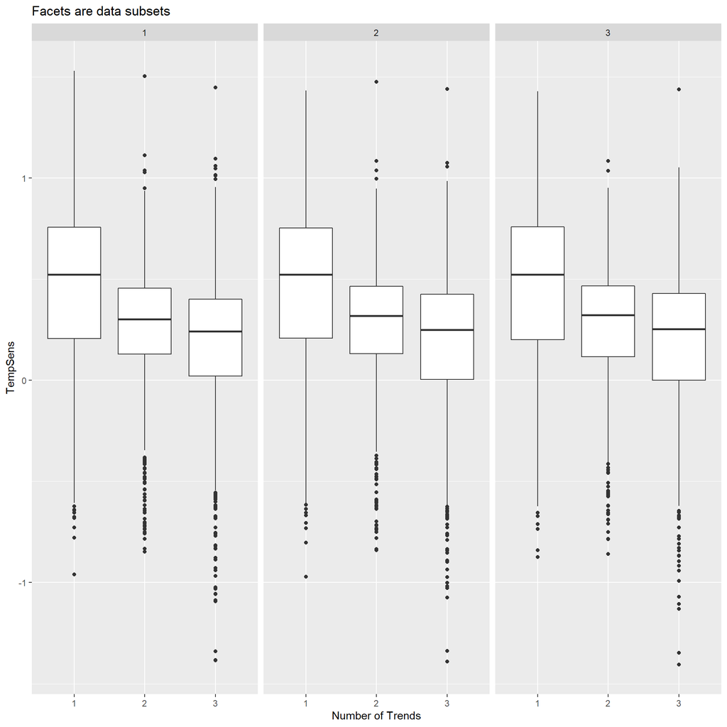

```r
dfa_results %>%
  distinct(TempSens, trends, subset) %>%
  ggplot(aes(x = as.factor(trends), y = TempSens)) +
  geom_boxplot() +
  facet_wrap(~subset) +
  labs(x = "Number of Trends", title = "Facets are data subsets")
```

Thermal sensitivity versus trend loadings. In the Bristol Bay analysis, there was a general pattern of sites with lower sensitivites loaded higher on the single trend. This is true for the single trend model, but not for the rest.

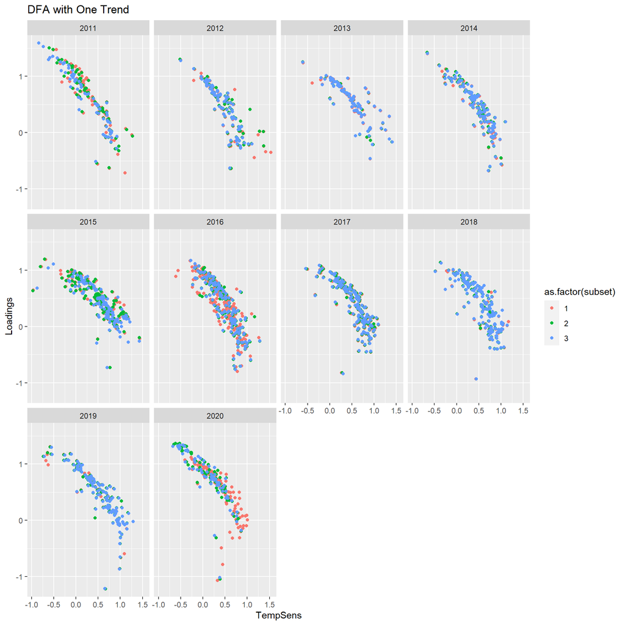

```r
dfa_results %>%
  filter(trends == 1) %>%
  ggplot(aes(TempSens, Loadings)) +
  geom_point(aes(color = as.factor(subset))) +
  facet_wrap(~Year) +
  labs(title = "DFA with One Trend")
```

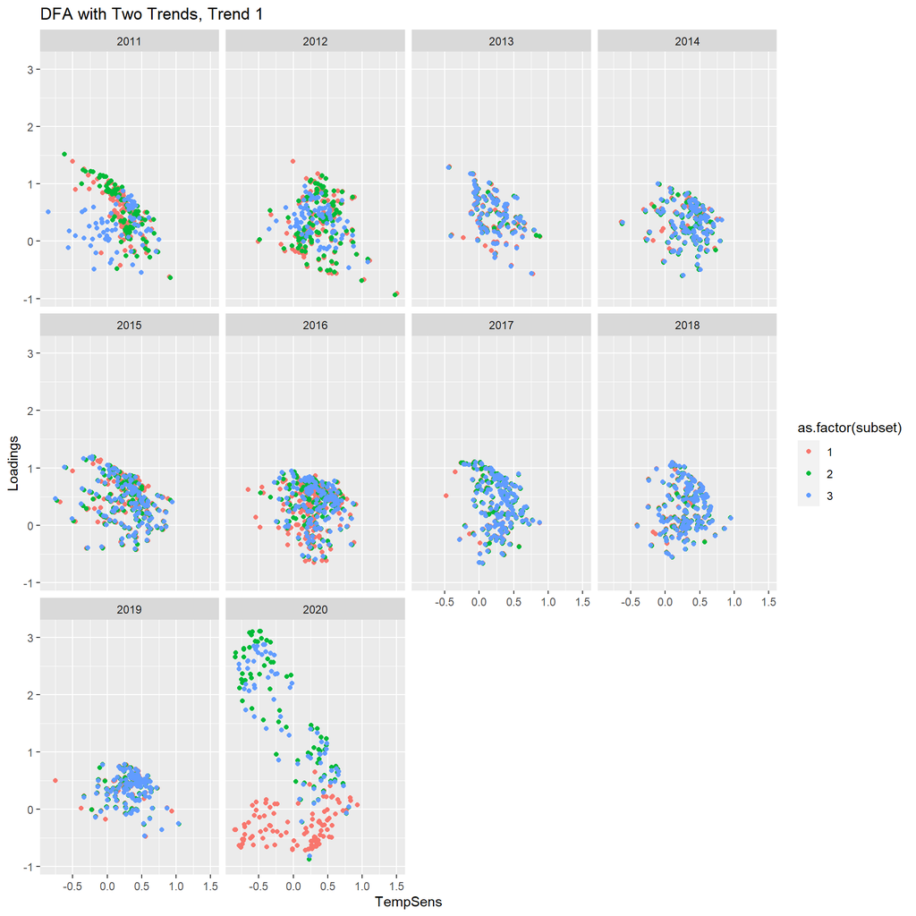

```r
dfa_results %>%
  filter(trends == 2, trend_no == 1) %>%
  ggplot(aes(TempSens, Loadings)) +
  geom_point(aes(color = as.factor(subset))) +
  facet_wrap(~Year) +
  labs(title = "DFA with Two Trends, Trend 1")
```

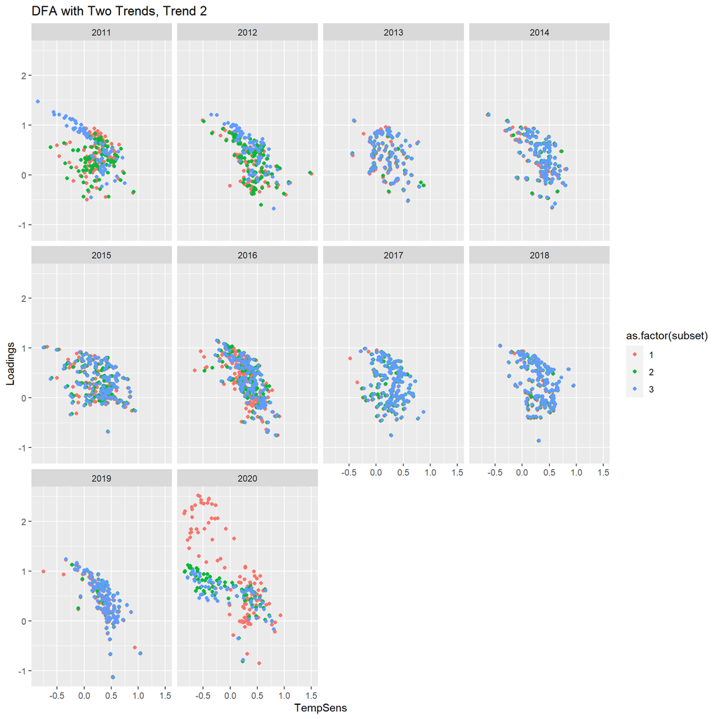

```r
dfa_results %>%
  filter(trends == 2, trend_no == 2) %>%
  ggplot(aes(TempSens, Loadings)) +
  geom_point(aes(color = as.factor(subset))) +
  facet_wrap(~Year) +
  labs(title = "DFA with Two Trends, Trend 2")
```

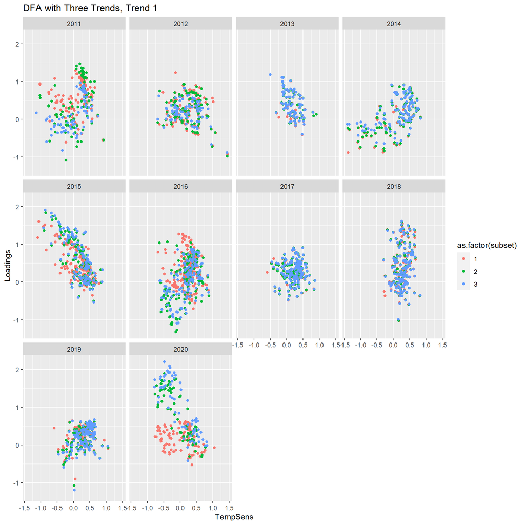

```r
dfa_results %>%
  filter(trends == 3, trend_no == 1) %>%
  ggplot(aes(TempSens, Loadings)) +
  geom_point(aes(color = as.factor(subset))) +
  facet_wrap(~Year) +
  labs(title = "DFA with Three Trends, Trend 1")
```

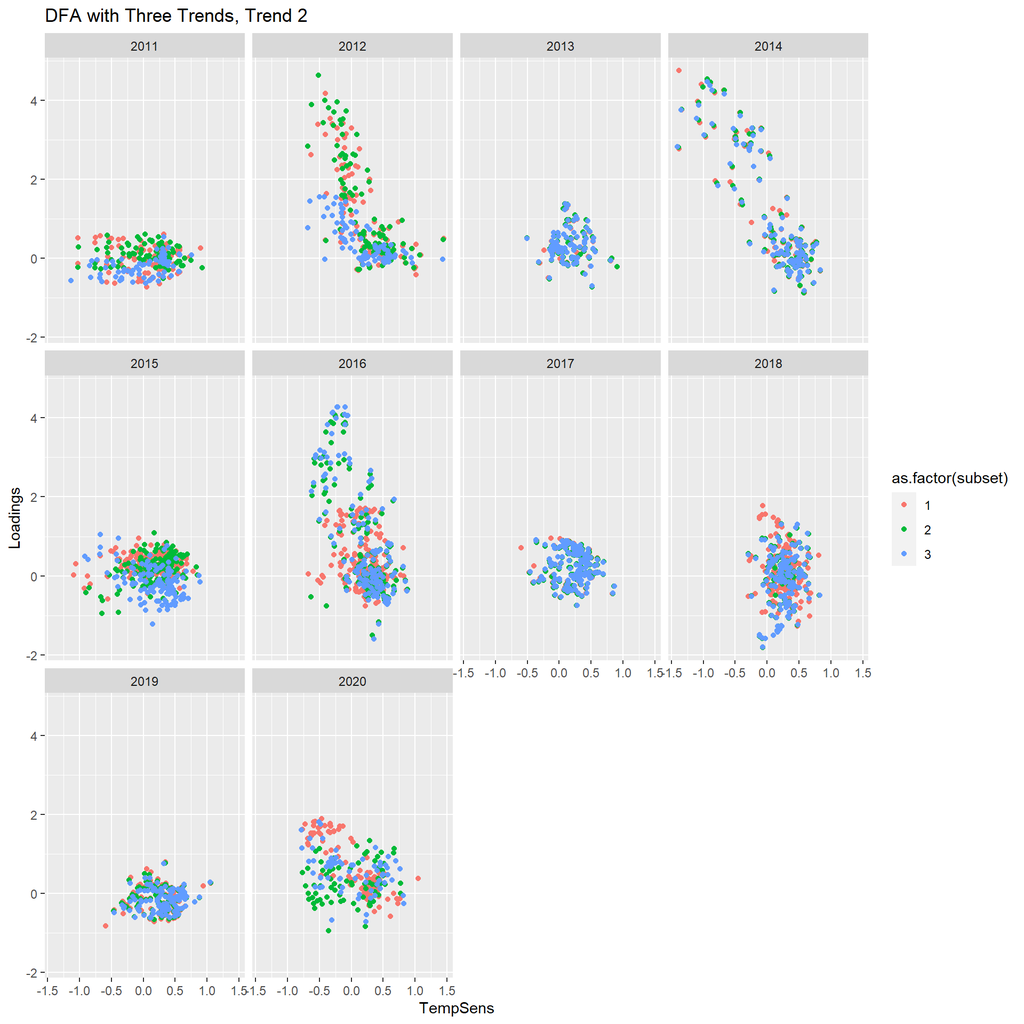

```r
dfa_results %>%
  filter(trends == 3, trend_no == 2) %>%
  ggplot(aes(TempSens, Loadings)) +
  geom_point(aes(color = as.factor(subset))) +
  facet_wrap(~Year) +
  labs(title = "DFA with Three Trends, Trend 2")
```

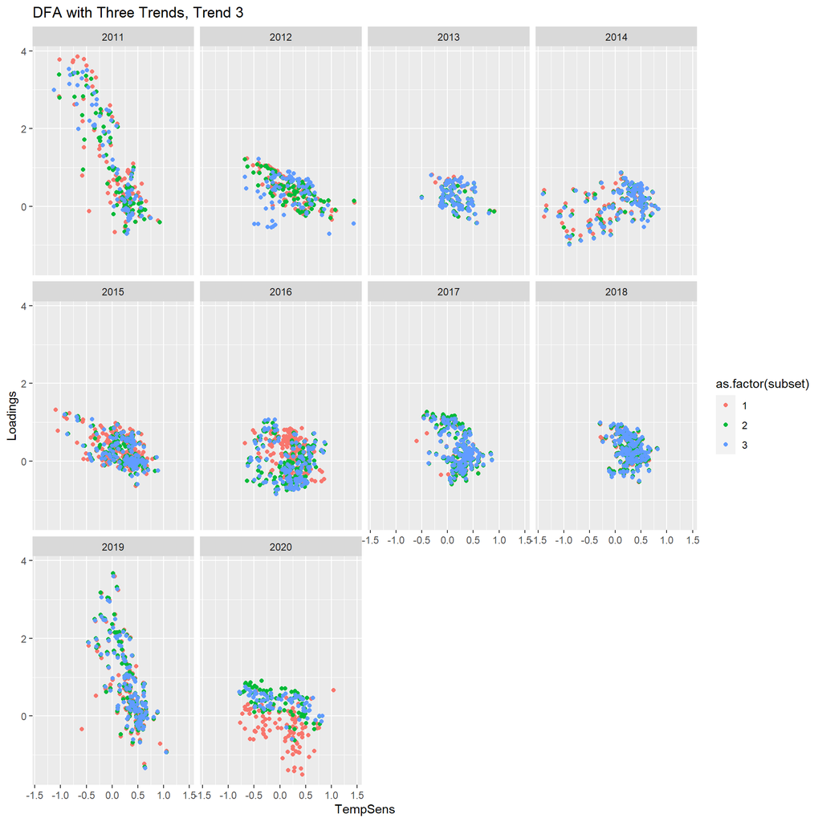

```r
dfa_results %>%
  filter(trends == 3, trend_no == 3) %>%
  ggplot(aes(TempSens, Loadings)) +
  geom_point(aes(color = as.factor(subset))) +
  facet_wrap(~Year) +
  labs(title = "DFA with Three Trends, Trend 3")
```

Frequency plots of thermal sensitivities by DFA (1, 2, or 3 trends), subset, year and region.

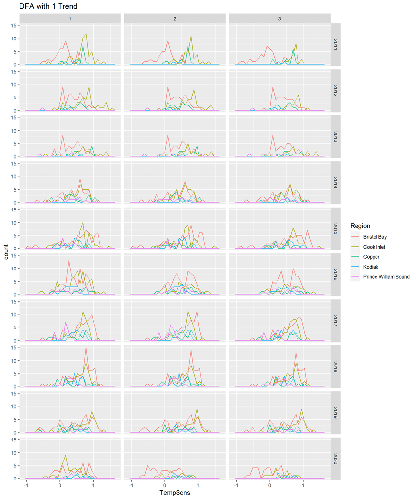

```r
dfa_results %>%
  filter(trends == 1) %>%
  ggplot(aes(TempSens)) +
  geom_freqpoly(aes(color = Region)) +
  facet_grid(rows = vars(Year), cols = vars(subset)) +
  labs(title = "DFA with 1 Trend")
```

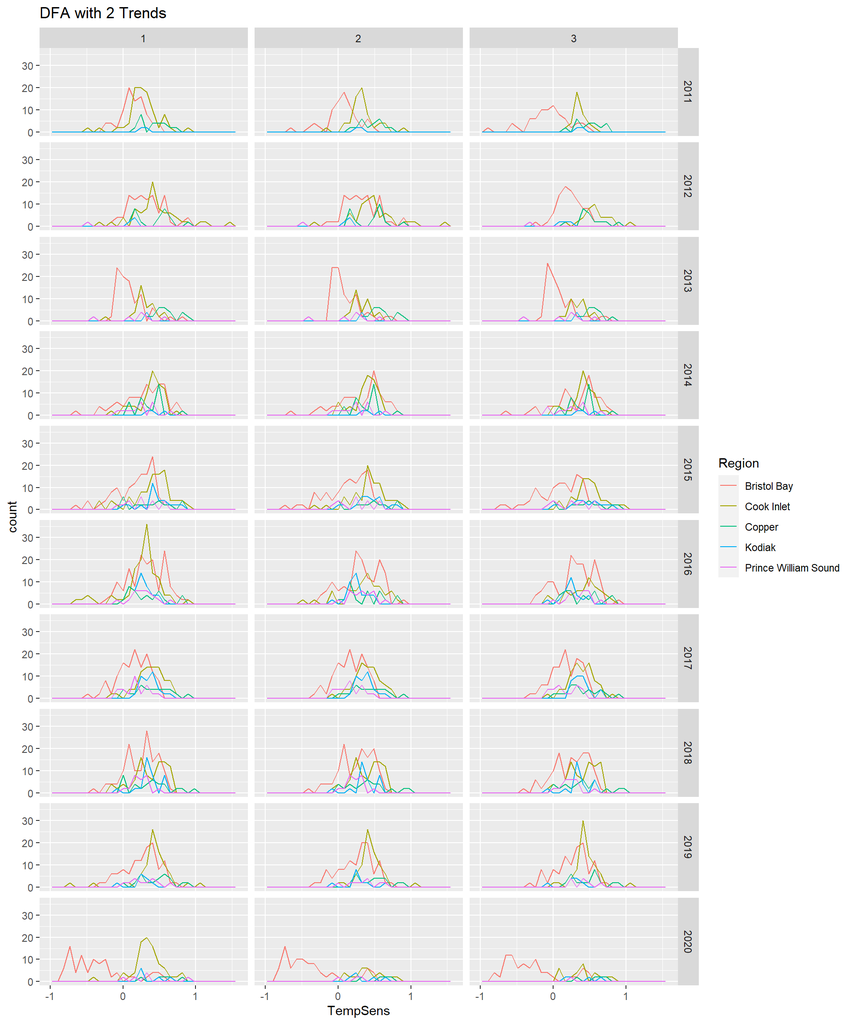

```r
dfa_results %>%
  filter(trends == 2) %>%
  ggplot(aes(TempSens)) +
  geom_freqpoly(aes(color = Region)) +
  facet_grid(rows = vars(Year), cols = vars(subset)) +
  labs(title = "DFA with 2 Trends")
```

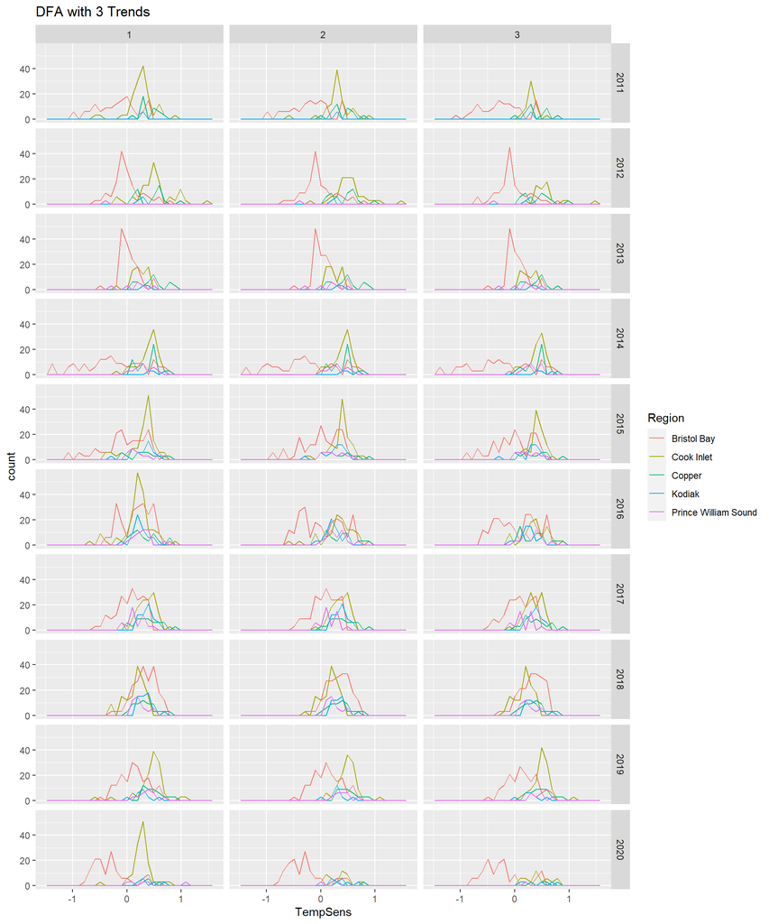

```r
dfa_results %>%
  filter(trends == 3) %>%
  ggplot(aes(TempSens)) +
  geom_freqpoly(aes(color = Region)) +
  facet_grid(rows = vars(Year), cols = vars(subset)) +
  labs(title = "DFA with 3 Trends")
```

From TC:

- It’s common/unsurprising that DFA’s with more trends are favored by AIC model selection. However, these multiple trend models are less interesting to our questions as they tend to have the same issue we were having in that some of the common trends are soaking up the air temperature variation.
- The single trend models look improved across the subsets so these may be useful as per our original intentions.

Plots of trends by different DFAs with 1, 2 and 3 trends.

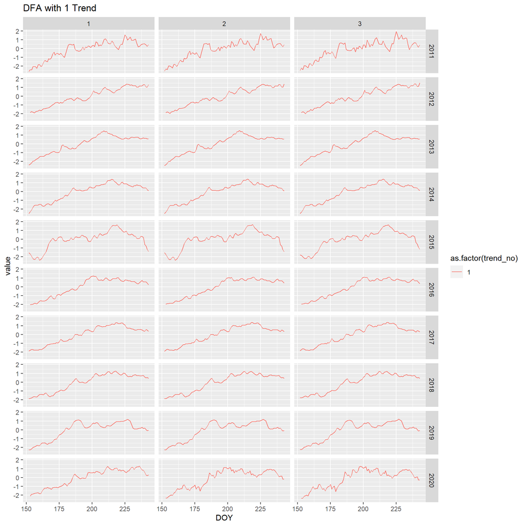

```r
trend_results %>%
  filter(trends == 1) %>%
  ggplot(aes(x = DOY, y = value, color = as.factor(trend_no))) +
  geom_line() +
  facet_grid(rows = vars(Year), cols = vars(subset)) +
  labs(title = "DFA with 1 Trend")
```

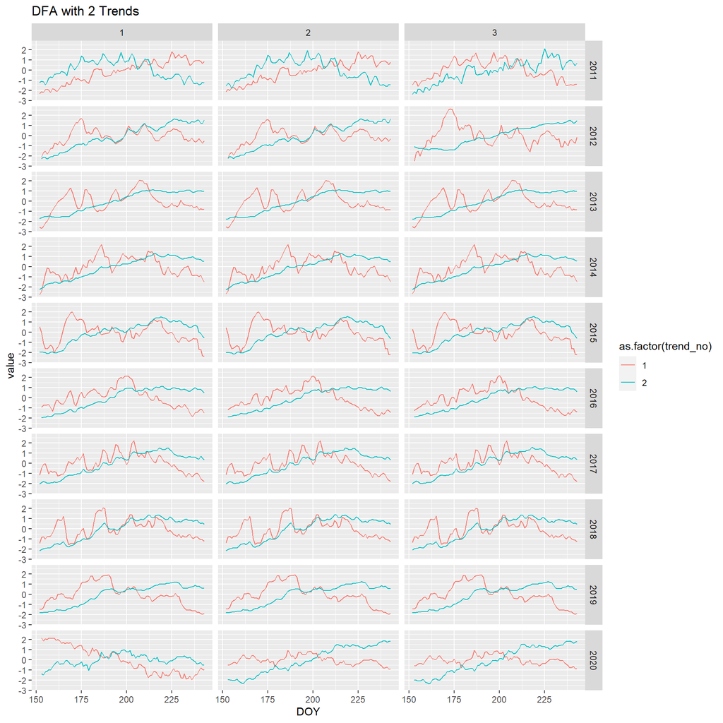

```r
trend_results %>%
  filter(trends == 2) %>%
  ggplot(aes(x = DOY, y = value, color = as.factor(trend_no))) +
  geom_line() +
  facet_grid(rows = vars(Year), cols = vars(subset)) +
  labs(title = "DFA with 2 Trends")
```

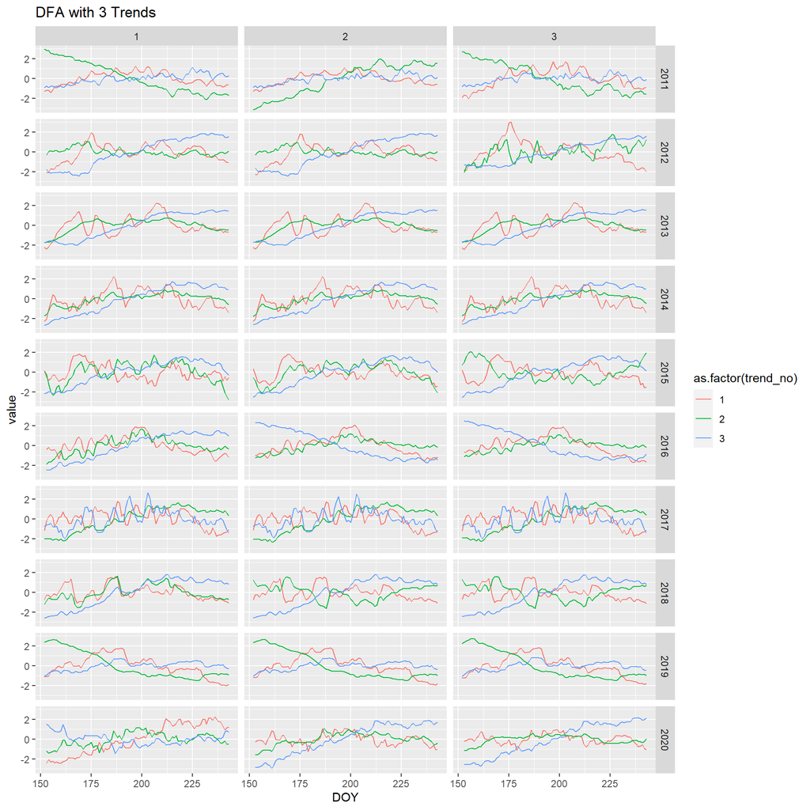

```r
trend_results %>%
  filter(trends == 3) %>%
  ggplot(aes(x = DOY, y = value, color = as.factor(trend_no))) +
  geom_line() +
  facet_grid(rows = vars(Year), cols = vars(subset)) +
  labs(title = "DFA with 3 Trends")
```

Exploration of how covariates relate to sites that load strongly onto the trend in DFA with one trend.

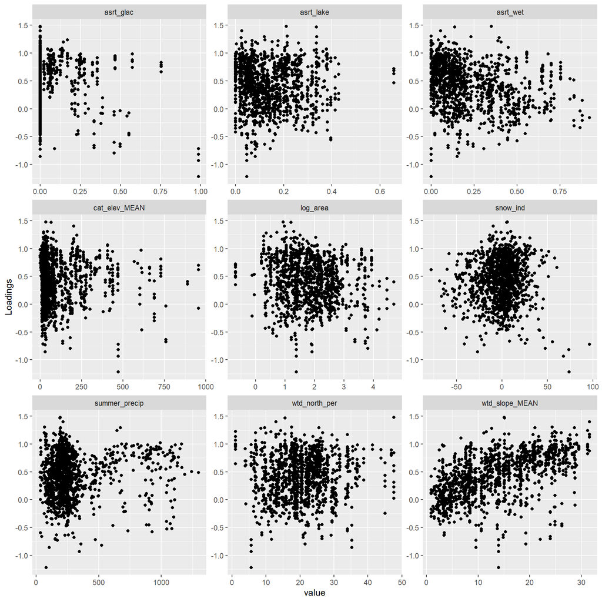

```r
mod_dat <- readRDS("data_preparation/final_data/model_data2022-02-08.rds")

left_join(dfa_results %>%
            filter(trends == 1, subset == 1) %>%
            select(SiteID, Year, TempSens, Loadings),
          mod_dat %>%
            select(SiteID = Site, Year, ar1_ts = TempSens, wtd_slope_MEAN, asrt_glac, log_area, snow_ind, cat_elev_MEAN, asrt_lake, asrt_wet, wtd_north_per, summer_precip)) %>%
  pivot_longer(cols = wtd_slope_MEAN:summer_precip, names_to = "vars", values_to = "value") %>%
  ggplot() +
  geom_point(aes(x = value, y = Loadings)) +
  facet_wrap(~vars, scales = "free")
```

## 1.2 AR1 Results

As an alternative modeling method to estimate stream thermal sensitivity, Tim used the air temperature coefficient in a time series model for each site and summer using an auto-regressive lag of 1 day on the residuals (AR1 model). These results better matched the patterns between air-stream temperatures at the different sites.

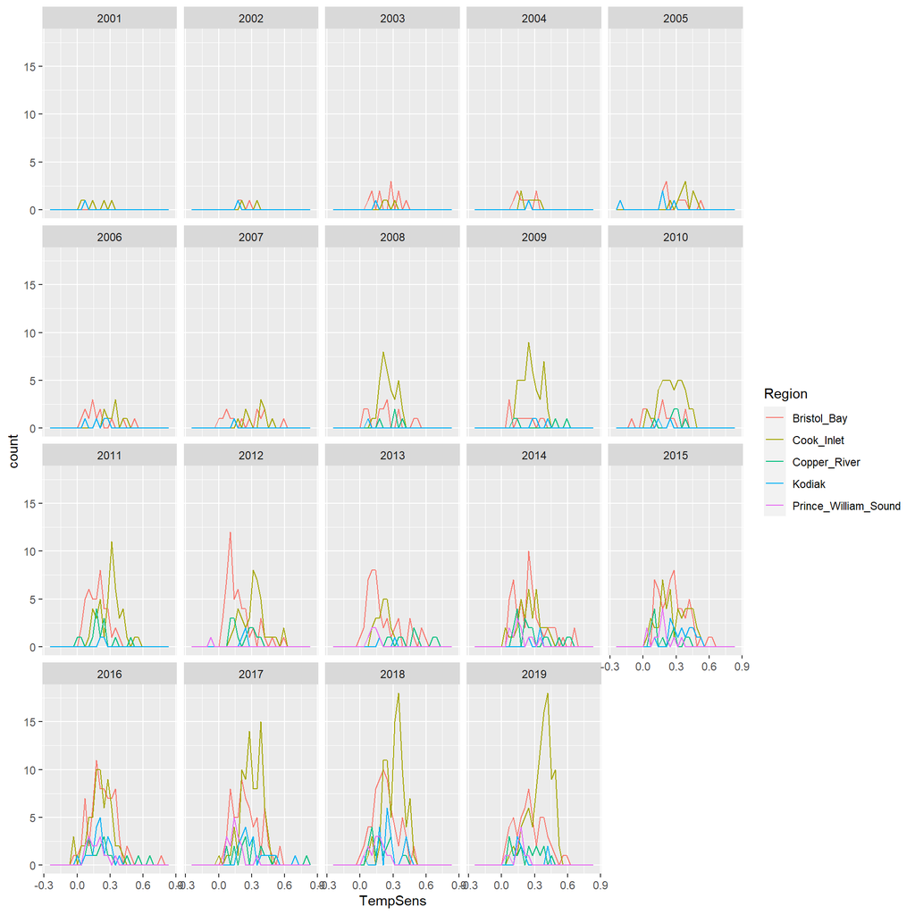

```r
mod_dat <- readRDS("data_preparation/final_data/model_data2022-02-08.rds")

mod_dat %>%
  ggplot(aes(TempSens)) +
  geom_freqpoly(aes(color = Region)) +
  facet_wrap(~Year)
```

Curious how the previous results compare to the TS from a DFA with one trend.

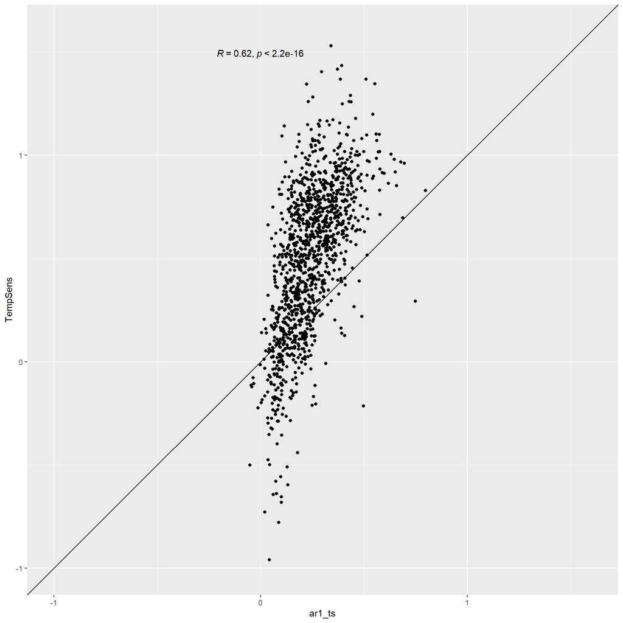

```r
left_join(mod_dat %>%
            select(SiteID = Site, Year, ar1_ts = TempSens),
          dfa_results %>%
            filter(trends == 1, subset == 1) %>%
            select(SiteID, Year, TempSens)) %>%
  ggplot(aes(x = ar1_ts, y = TempSens)) +
  geom_point() +
  geom_abline(aes(intercept = 0, slope = 1)) +
  coord_cartesian(xlim = c(-1, 1.6), ylim = c(-1, 1.6)) +
  stat_cor()
```

# 2 CART analysis

Note: everything below is based on TS from the AR1 model.

Using rpart to create a regression tree with all of the data.

```r
ct_all <- rpart(TempSens ~ log_slope + log_cat_elev + log_cat_slope + wtd_north_per +
                      wtd_slope_MEAN + log_area + dist_coast_km + asrt_wet +
                      asrt_glac + asrt_lake + snow_ind + summer_precip,
                    data = mod_dat, method = "anova")
```

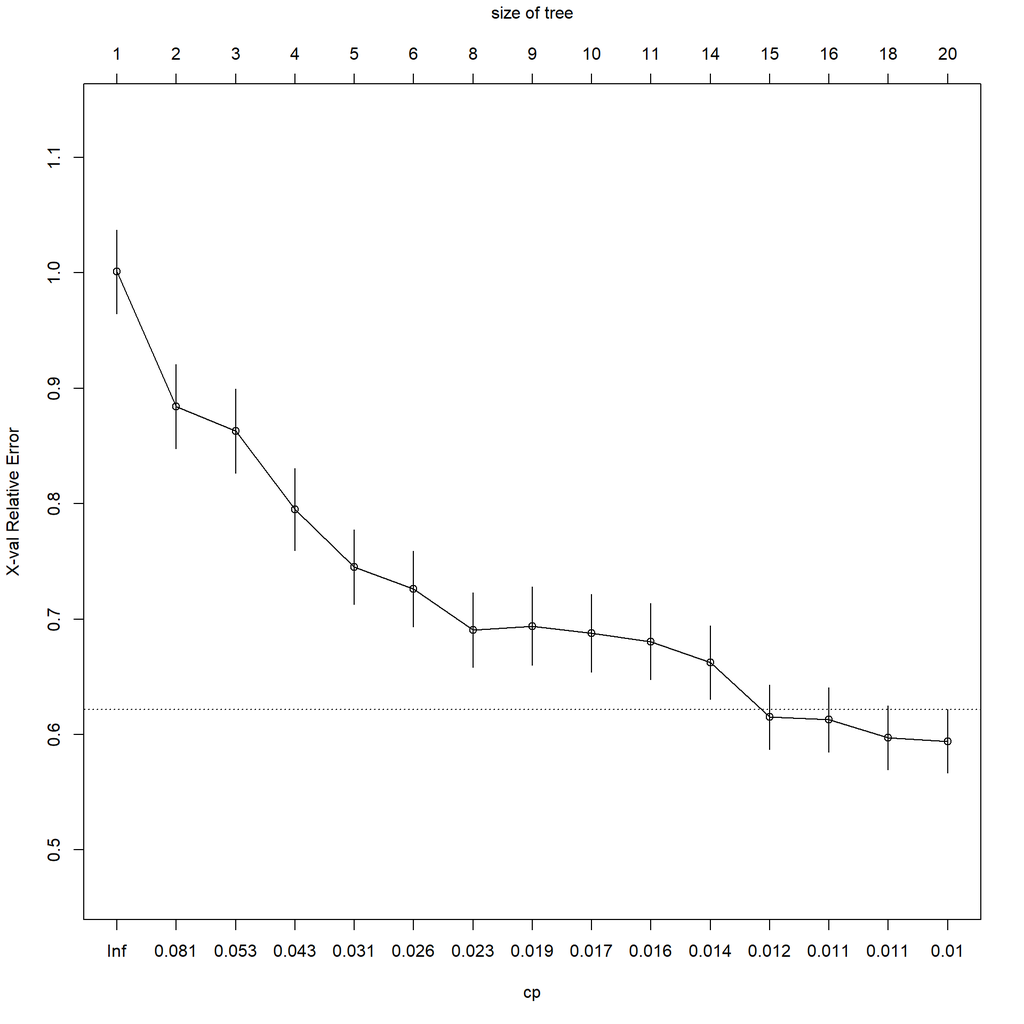

```r
plotcp(ct_all)
```

```r
printcp(ct_all)
```

```
##
## Regression tree:
## rpart(formula = TempSens ~ log_slope + log_cat_elev + log_cat_slope +
##     wtd_north_per + wtd_slope_MEAN + log_area + dist_coast_km +
##     asrt_wet + asrt_glac + asrt_lake + snow_ind + summer_precip,
##     data = mod_dat, method = "anova")
##
## Variables actually used in tree construction:
## [1] asrt_lake      asrt_wet       dist_coast_km  log_area       log_cat_elev
## [6] log_cat_slope  snow_ind       summer_precip  wtd_slope_MEAN
##
## Root node error: 26.151/1668 = 0.015678
##
## n= 1668
##
##          CP nsplit rel error  xerror     xstd
## 1  0.117823      0   1.00000 1.00086 0.036095
## 2  0.056083      1   0.88218 0.88405 0.036600
## 3  0.050974      2   0.82609 0.86294 0.036604
## 4  0.036374      3   0.77512 0.79484 0.035604
## 5  0.026689      4   0.73875 0.74513 0.032318
## 6  0.025873      5   0.71206 0.72604 0.032777
## 7  0.020373      7   0.66031 0.69065 0.032439
## 8  0.017639      8   0.63994 0.69401 0.034100
## 9  0.016017      9   0.62230 0.68787 0.033705
## 10 0.015695     10   0.60628 0.68056 0.033157
## 11 0.011835     13   0.55920 0.66243 0.031775
## 12 0.011445     14   0.54737 0.61504 0.027933
## 13 0.010847     15   0.53592 0.61283 0.027977
## 14 0.010411     17   0.51423 0.59715 0.027671
## 15 0.010000     19   0.49341 0.59417 0.027536
```

```r
cp_parm <- 0.011197
```

Prune the tree and print the results.

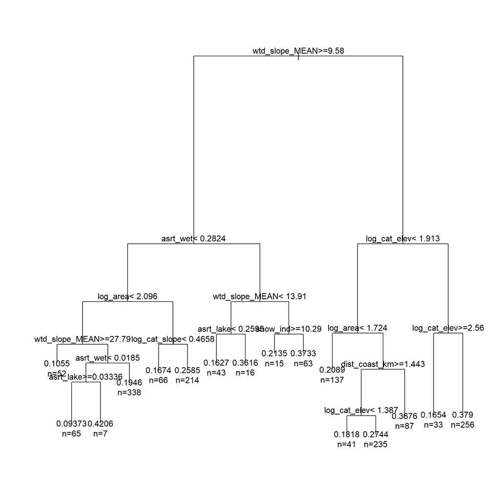

```r
ct_pr <- prune(ct_all, cp = cp_parm)

# print(ct_pr)

par(xpd = TRUE)
plot(ct_pr, compress = TRUE)
text(ct_pr, use.n = TRUE)
```

Summary table indicates variable importance and also lists surrogate splits. Interesting that snow index and precipitation are the least important variables.

```r
summary(ct_pr)
```

```
## Call:
## rpart(formula = TempSens ~ log_slope + log_cat_elev + log_cat_slope +
##     wtd_north_per + wtd_slope_MEAN + log_area + dist_coast_km +
##     asrt_wet + asrt_glac + asrt_lake + snow_ind + summer_precip,
##     data = mod_dat, method = "anova")
##   n= 1668
##
##            CP nsplit rel error    xerror       xstd
## 1  0.11782308      0 1.0000000 1.0008627 0.03609548
## 2  0.05608274      1 0.8821769 0.8840508 0.03659966
## 3  0.05097418      2 0.8260942 0.8629442 0.03660411
## 4  0.03637352      3 0.7751200 0.7948424 0.03560415
## 5  0.02668900      4 0.7387465 0.7451323 0.03231778
## 6  0.02587251      5 0.7120575 0.7260365 0.03277667
## 7  0.02037349      7 0.6603125 0.6906537 0.03243893
## 8  0.01763869      8 0.6399390 0.6940148 0.03409980
## 9  0.01601656      9 0.6223003 0.6878726 0.03370482
## 10 0.01569466     10 0.6062837 0.6805592 0.03315748
## 11 0.01183466     13 0.5591997 0.6624260 0.03177540
## 12 0.01144498     14 0.5473651 0.6150397 0.02793343
## 13 0.01119700     15 0.5359201 0.6128309 0.02797677
##
## Variable importance
## wtd_slope_MEAN  dist_coast_km       asrt_wet   log_cat_elev  log_cat_slope
##             17             15             14             13              8
##       log_area      asrt_lake      log_slope      asrt_glac  wtd_north_per
##              8              7              5              4              4
##       snow_ind  summer_precip
##              3              1
##
## Node number 1: 1668 observations,    complexity param=0.1178231
##   mean=0.2524974, MSE=0.01567779
##   left son=2 (879 obs) right son=3 (789 obs)
##   Primary splits:
##       wtd_slope_MEAN < 9.580174    to the right, improve=0.11782310, (0 missing)
##       dist_coast_km  < 83.65199    to the left,  improve=0.08603335, (0 missing)
##       asrt_wet       < 0.279366    to the left,  improve=0.06215807, (0 missing)
##       log_cat_elev   < 1.912884    to the left,  improve=0.05125803, (0 missing)
##       log_cat_slope  < 1.038689    to the right, improve=0.04947506, (0 missing)
##   Surrogate splits:
```

[output cut: 250 more lines]

```
##
## Node number 35: 338 observations
##   mean=0.1945501, MSE=0.009579591
##
## Node number 52: 41 observations
##   mean=0.1818131, MSE=0.009323335
##
## Node number 53: 235 observations
##   mean=0.2744058, MSE=0.007173091
##
## Node number 68: 65 observations
##   mean=0.0937271, MSE=0.004010371
##
## Node number 69: 7 observations
##   mean=0.4206056, MSE=0.001225491
```

## 2.1 Cook Inlet Regression Tree

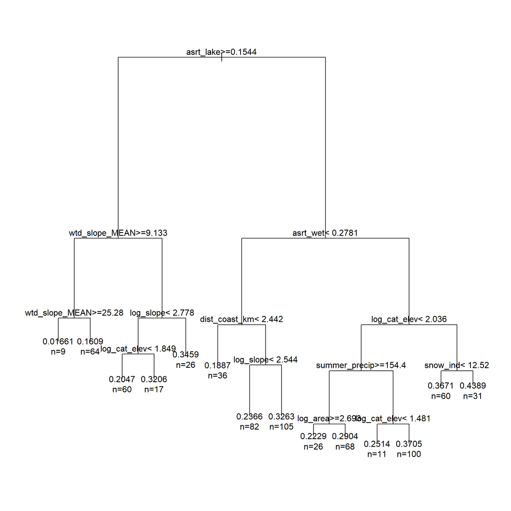

```r
ct_ci <- rpart(TempSens ~ log_slope + log_cat_elev + log_cat_slope + wtd_north_per +
                      wtd_slope_MEAN + log_area + dist_coast_km + asrt_wet +
                      asrt_glac + asrt_lake + snow_ind + summer_precip,
                    data = mod_dat %>% filter(Region == "Cook_Inlet"), method = "anova")
# plotcp(ct_ci)
# printcp(ct_ci)
cp_parm <- 0.010000
ct_cipr <- prune(ct_ci, cp = cp_parm)

par(xpd = TRUE)
plot(ct_cipr, compress = TRUE)
text(ct_cipr, use.n = TRUE)
```

Summary table indicates variable importance and also lists surrogate splits. Interesting that snow index and precipitation are the least important variables.

```r
summary(ct_cipr)
```

```
## Call:
## rpart(formula = TempSens ~ log_slope + log_cat_elev + log_cat_slope +
##     wtd_north_per + wtd_slope_MEAN + log_area + dist_coast_km +
##     asrt_wet + asrt_glac + asrt_lake + snow_ind + summer_precip,
##     data = mod_dat %>% filter(Region == "Cook_Inlet"), method = "anova")
##   n= 695
##
##            CP nsplit rel error    xerror       xstd
## 1  0.16380760      0 1.0000000 1.0031776 0.04919116
## 2  0.07809174      1 0.8361924 0.8737209 0.04464957
## 3  0.07227784      2 0.7581007 0.8223652 0.04357129
## 4  0.04490585      3 0.6858228 0.7020110 0.03708053
## 5  0.04132557      5 0.5960111 0.6943184 0.03860431
## 6  0.03246605      7 0.5133600 0.6017656 0.03439365
## 7  0.02223091      8 0.4808939 0.5701840 0.03270425
## 8  0.02051001      9 0.4586630 0.5567392 0.03285948
## 9  0.01758050     10 0.4381530 0.5479694 0.03265760
## 10 0.01313623     11 0.4205725 0.5121412 0.03181566
## 11 0.01071056     12 0.4074363 0.4770345 0.02873524
## 12 0.01000000     13 0.3967257 0.4775436 0.02842861
##
## Variable importance
##      asrt_lake   log_cat_elev wtd_slope_MEAN       asrt_wet      log_slope
##             13             12             11             11              9
##  log_cat_slope  dist_coast_km      asrt_glac  wtd_north_per  summer_precip
##              9              9              8              8              4
##       log_area       snow_ind
##              4              2
##
## Node number 1: 695 observations,    complexity param=0.1638076
##   mean=0.2857732, MSE=0.01151821
##   left son=2 (176 obs) right son=3 (519 obs)
##   Primary splits:
##       asrt_lake      < 0.1543653  to the right, improve=0.1638076, (0 missing)
##       wtd_slope_MEAN < 12.1582    to the right, improve=0.1488056, (0 missing)
##       asrt_glac      < 0.02317135 to the right, improve=0.1442814, (0 missing)
##       dist_coast_km  < 81.94809   to the left,  improve=0.1345888, (0 missing)
##       asrt_wet       < 0.27811    to the left,  improve=0.1238370, (0 missing)
##   Surrogate splits:
##       log_cat_elev   < 1.430724   to the left,  agree=0.799, adj=0.205, (0 split)
```

[output cut: 218 more lines]

```
##
## Node number 31: 31 observations
##   mean=0.4388592, MSE=0.002053741
##
## Node number 56: 26 observations
##   mean=0.2228636, MSE=0.003864899
##
## Node number 57: 68 observations
##   mean=0.2903807, MSE=0.003833664
##
## Node number 58: 11 observations
##   mean=0.2513778, MSE=0.004558127
##
## Node number 59: 100 observations
##   mean=0.3705475, MSE=0.004929854
```

## 2.2 Bristol Bay Regression Tree

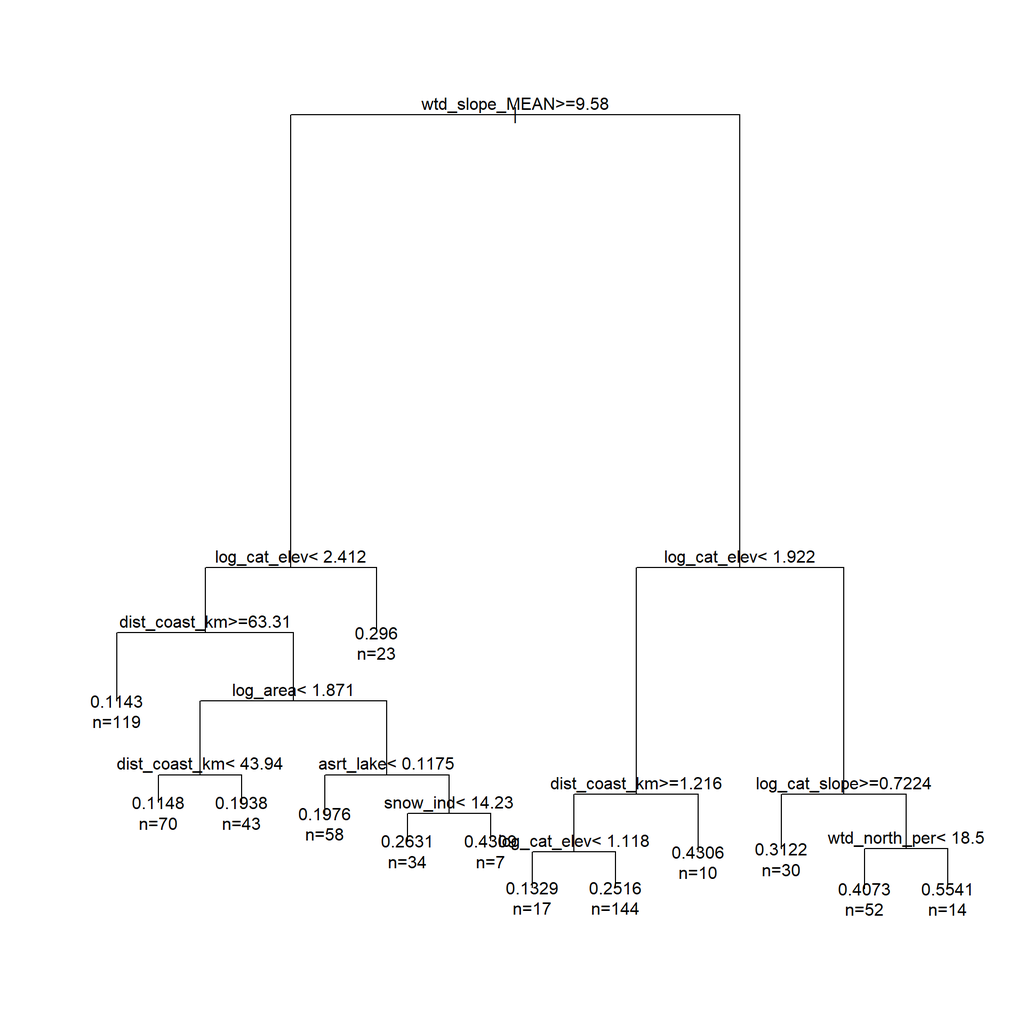

```r
ct_bb <- rpart(TempSens ~ log_slope + log_cat_elev + log_cat_slope + wtd_north_per +
                      wtd_slope_MEAN + log_area + dist_coast_km + asrt_wet +
                      asrt_glac + asrt_lake + snow_ind + summer_precip,
                    data = mod_dat %>% filter(Region == "Bristol_Bay"), method = "anova")

# plotcp(ct_bb)
# printcp(ct_bb)
cp_parm <- 0.014908
ct_bbpr <- prune(ct_bb, cp = cp_parm)

par(xpd = TRUE)
plot(ct_bbpr, compress = TRUE)
text(ct_bbpr, use.n = TRUE)
```

```r
summary(ct_bbpr)
```

```
## Call:
## rpart(formula = TempSens ~ log_slope + log_cat_elev + log_cat_slope +
##     wtd_north_per + wtd_slope_MEAN + log_area + dist_coast_km +
##     asrt_wet + asrt_glac + asrt_lake + snow_ind + summer_precip,
##     data = mod_dat %>% filter(Region == "Bristol_Bay"), method = "anova")
##   n= 621
##
##            CP nsplit rel error    xerror       xstd
## 1  0.25953044      0 1.0000000 1.0005917 0.06173376
## 2  0.12987564      1 0.7404696 0.7443087 0.05415674
## 3  0.03959423      2 0.6105939 0.6224674 0.04948701
## 4  0.03298561      5 0.4918112 0.5484728 0.04151707
## 5  0.03137604      6 0.4588256 0.5180131 0.03992290
## 6  0.02267671      7 0.4274496 0.4813919 0.03774179
## 7  0.02043613      8 0.4047729 0.4841456 0.03756032
## 8  0.02031043      9 0.3843367 0.4654827 0.03553271
## 9  0.01585383     10 0.3640263 0.4323894 0.03456238
## 10 0.01560501     11 0.3481725 0.4178545 0.03377389
## 11 0.01490800     12 0.3325675 0.4126076 0.03373136
##
## Variable importance
## wtd_slope_MEAN  dist_coast_km   log_cat_elev  log_cat_slope       asrt_wet
##             19             16             15             13             10
##      log_slope  wtd_north_per       log_area      asrt_lake       snow_ind
##              6              6              5              5              3
##  summer_precip      asrt_glac
##              2              1
##
## Node number 1: 621 observations,    complexity param=0.2595304
##   mean=0.2275389, MSE=0.01687178
##   left son=2 (354 obs) right son=3 (267 obs)
##   Primary splits:
##       wtd_slope_MEAN < 9.580174   to the right, improve=0.25953040, (0 missing)
##       dist_coast_km  < 89.79      to the left,  improve=0.17135100, (0 missing)
##       log_cat_elev   < 1.922195   to the left,  improve=0.14183210, (0 missing)
##       log_area       < 1.059222   to the left,  improve=0.07948351, (0 missing)
##       log_cat_slope  < 0.1757259  to the right, improve=0.06306649, (0 missing)
##   Surrogate splits:
##       log_cat_slope < 0.3241142  to the right, agree=0.728, adj=0.367, (0 split)
##       dist_coast_km < 75.46811   to the left,  agree=0.665, adj=0.221, (0 split)
```

[output cut: 190 more lines]

```
##       snow_ind      < 14.23106   to the left,  improve=0.27308330, (0 missing)
##       log_area      < 3.097242   to the right, improve=0.12753860, (0 missing)
##       log_slope     < 1.888294   to the left,  improve=0.09216125, (0 missing)
##       asrt_glac     < 0.05627204 to the right, improve=0.08287556, (0 missing)
##       log_cat_slope < 0.5178313  to the left,  improve=0.06448692, (0 missing)
##   Surrogate splits:
##       log_cat_elev < 1.433653   to the right, agree=0.854, adj=0.143, (0 split)
##       asrt_wet     < 0.1627986  to the left,  agree=0.854, adj=0.143, (0 split)
##       asrt_lake    < 0.3716728  to the left,  agree=0.854, adj=0.143, (0 split)
##
## Node number 78: 34 observations
##   mean=0.2630823, MSE=0.006950726
##
## Node number 79: 7 observations
##   mean=0.4309093, MSE=0.02841325
```

## 2.3 Kodiak Regression Tree

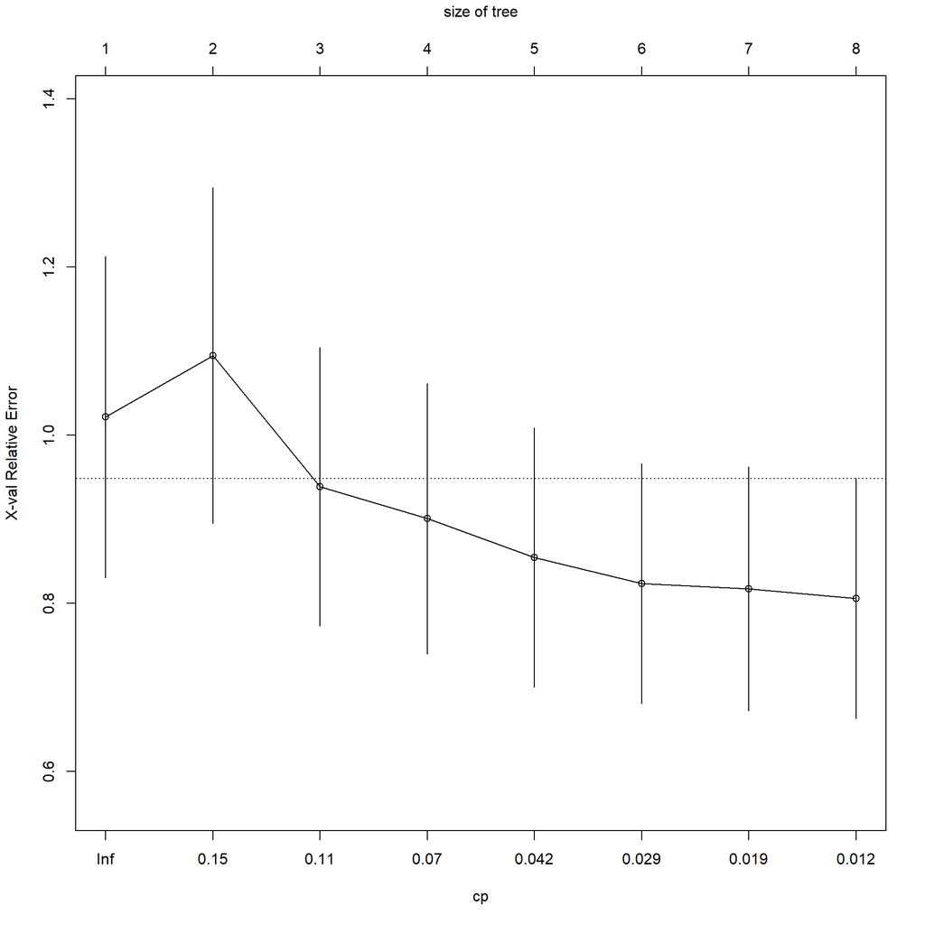

```r
ct_kod <- rpart(TempSens ~ log_slope + log_cat_elev + log_cat_slope + wtd_north_per +
                      wtd_slope_MEAN + log_area + dist_coast_km + asrt_wet +
                      asrt_glac + asrt_lake + snow_ind + summer_precip,
                    data = mod_dat %>% filter(Region == "Kodiak"), method = "anova")
plotcp(ct_kod)
```

```r
printcp(ct_kod)
```

```
##
## Regression tree:
## rpart(formula = TempSens ~ log_slope + log_cat_elev + log_cat_slope +
##     wtd_north_per + wtd_slope_MEAN + log_area + dist_coast_km +
##     asrt_wet + asrt_glac + asrt_lake + snow_ind + summer_precip,
##     data = mod_dat %>% filter(Region == "Kodiak"), method = "anova")
##
## Variables actually used in tree construction:
## [1] asrt_wet      log_area      log_cat_slope snow_ind      summer_precip
##
## Root node error: 1.6995/112 = 0.015174
##
## n= 112
##
##         CP nsplit rel error  xerror    xstd
## 1 0.172697      0   1.00000 1.02173 0.19099
## 2 0.136208      1   0.82730 1.09477 0.19976
## 3 0.090861      2   0.69110 0.93893 0.16573
## 4 0.053756      3   0.60023 0.90086 0.16077
## 5 0.033359      4   0.54648 0.85480 0.15420
## 6 0.025739      5   0.51312 0.82357 0.14273
## 7 0.013759      6   0.48738 0.81725 0.14482
## 8 0.010000      7   0.47362 0.80588 0.14290
```

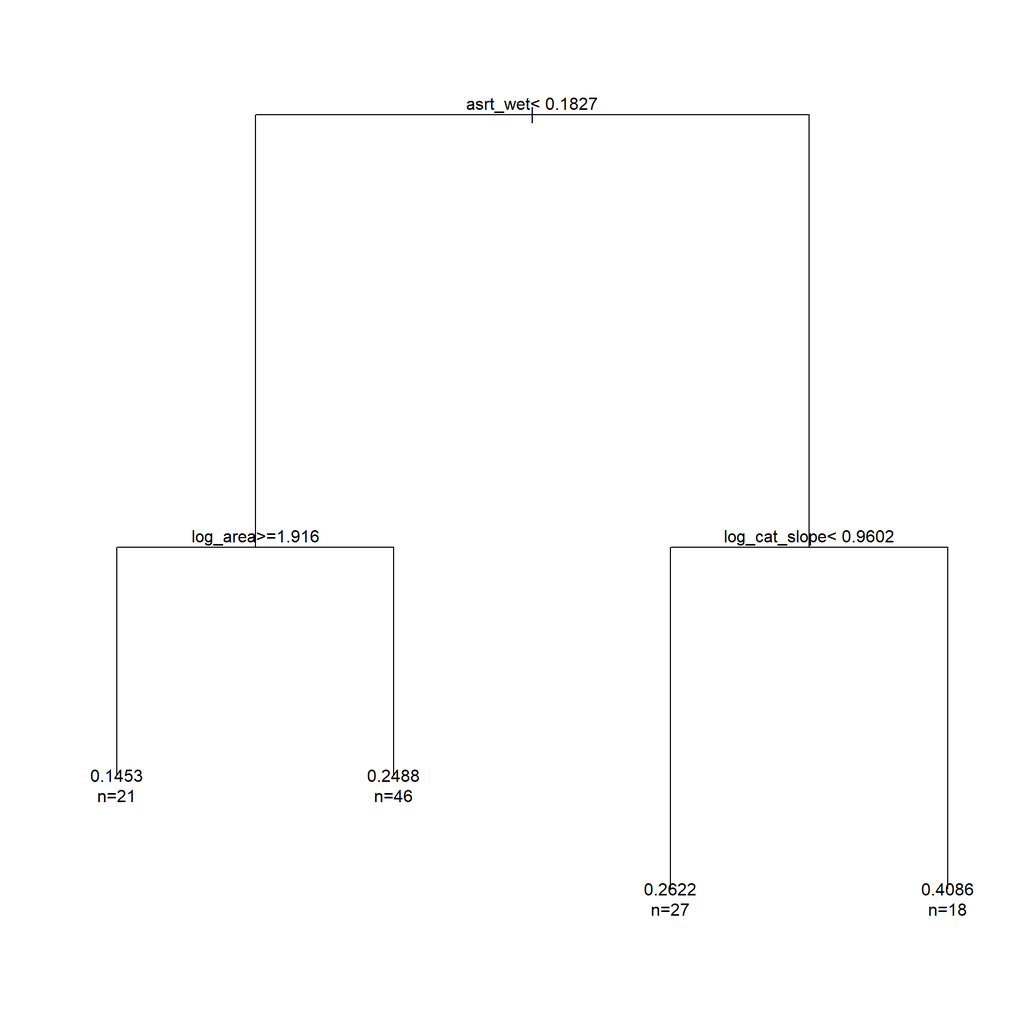

```r
cp_parm <- 0.053756
ct_kodpr <- prune(ct_kod, cp = cp_parm)

par(xpd = TRUE)
plot(ct_kodpr, compress = TRUE)
text(ct_kodpr, use.n = TRUE)
```

```r
summary(ct_kodpr)
```

```
## Call:
## rpart(formula = TempSens ~ log_slope + log_cat_elev + log_cat_slope +
##     wtd_north_per + wtd_slope_MEAN + log_area + dist_coast_km +
##     asrt_wet + asrt_glac + asrt_lake + snow_ind + summer_precip,
##     data = mod_dat %>% filter(Region == "Kodiak"), method = "anova")
##   n= 112
##
##           CP nsplit rel error    xerror      xstd
## 1 0.17269692      0 1.0000000 1.0217323 0.1909889
## 2 0.13620782      1 0.8273031 1.0947676 0.1997634
## 3 0.09086104      2 0.6910953 0.9389311 0.1657287
## 4 0.05375600      3 0.6002342 0.9008572 0.1607728
##
## Variable importance
##       log_area       asrt_wet  wtd_north_per      log_slope wtd_slope_MEAN
##             17             16             13             13             12
##       snow_ind  log_cat_slope   log_cat_elev      asrt_glac
##             10              9              6              5
##
## Node number 1: 112 observations,    complexity param=0.1726969
##   mean=0.2582698, MSE=0.0151737
##   left son=2 (67 obs) right son=3 (45 obs)
##   Primary splits:
##       asrt_wet       < 0.1826873  to the left,  improve=0.1726969, (0 missing)
##       wtd_north_per  < 25.35906   to the right, improve=0.1527063, (0 missing)
##       log_cat_elev   < 1.638385   to the left,  improve=0.1433621, (0 missing)
##       wtd_slope_MEAN < 18.39747   to the right, improve=0.1233673, (0 missing)
##       log_slope      < 3.650677   to the right, improve=0.1223966, (0 missing)
##   Surrogate splits:
##       wtd_north_per  < 24.28999   to the right, agree=0.893, adj=0.733, (0 split)
##       wtd_slope_MEAN < 15.79473   to the right, agree=0.884, adj=0.711, (0 split)
##       log_area       < 2.140731   to the left,  agree=0.812, adj=0.533, (0 split)
##       snow_ind       < -22.1083   to the right, agree=0.812, adj=0.533, (0 split)
##       log_slope      < 3.20921    to the right, agree=0.786, adj=0.467, (0 split)
##
## Node number 2: 67 observations,    complexity param=0.09086104
##   mean=0.2163174, MSE=0.009518571
##   left son=4 (21 obs) right son=5 (46 obs)
##   Primary splits:
##       log_area       < 1.915582   to the right, improve=0.2421255, (0 missing)
```

[output cut: 23 more lines]

```
##       log_cat_elev   < 2.114377   to the left,  agree=0.800, adj=0.500, (0 split)
##       log_slope      < 2.967167   to the left,  agree=0.778, adj=0.444, (0 split)
##       wtd_slope_MEAN < 16.61288   to the left,  agree=0.778, adj=0.444, (0 split)
##
## Node number 4: 21 observations
##   mean=0.1452655, MSE=0.0115241
##
## Node number 5: 46 observations
##   mean=0.2487541, MSE=0.005246174
##
## Node number 6: 27 observations
##   mean=0.2621719, MSE=0.01180659
##
## Node number 7: 18 observations
##   mean=0.4085728, MSE=0.01210902
```

## 2.4 Prince William Sound Regression Tree

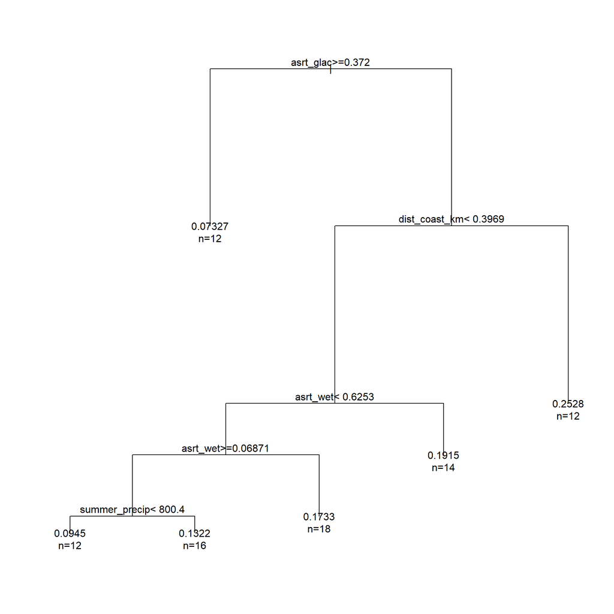

```r
ct_pws <- rpart(TempSens ~ log_slope + log_cat_elev + log_cat_slope + wtd_north_per +
                      wtd_slope_MEAN + log_area + dist_coast_km + asrt_wet +
                      asrt_glac + asrt_lake + snow_ind + summer_precip,
                    data = mod_dat %>% filter(Region == "Prince_William_Sound"), method = "anova")
 # plotcp(ct_pws)
 # printcp(ct_pws)
cp_parm <- 0.020529
ct_pwspr <- prune(ct_pws, cp = cp_parm)

par(xpd = TRUE)
plot(ct_pwspr, compress = TRUE)
text(ct_pwspr, use.n = TRUE)
```

```r
summary(ct_pwspr)
```

```
## Call:
## rpart(formula = TempSens ~ log_slope + log_cat_elev + log_cat_slope +
##     wtd_north_per + wtd_slope_MEAN + log_area + dist_coast_km +
##     asrt_wet + asrt_glac + asrt_lake + snow_ind + summer_precip,
##     data = mod_dat %>% filter(Region == "Prince_William_Sound"),
##     method = "anova")
##   n= 84
##
##           CP nsplit rel error    xerror      xstd
## 1 0.20640694      0 1.0000000 1.0213591 0.1841805
## 2 0.06961556      2 0.5871861 0.7707924 0.1284570
## 3 0.02052914      4 0.4479550 0.7190699 0.1422128
## 4 0.01000000      5 0.4274259 0.6678279 0.1266093
##
## Variable importance
##  dist_coast_km       snow_ind      log_slope      asrt_glac wtd_slope_MEAN
##             16             13             12             11              9
##   log_cat_elev       log_area       asrt_wet  log_cat_slope  summer_precip
##              9              9              8              7              2
##  wtd_north_per      asrt_lake
##              2              1
##
## Node number 1: 84 observations,    complexity param=0.2064069
##   mean=0.1543175, MSE=0.005652681
##   left son=2 (12 obs) right son=3 (72 obs)
##   Primary splits:
##       asrt_glac < 0.3719847  to the right, improve=0.1936529, (0 missing)
##       log_area  < 1.241879   to the right, improve=0.1856081, (0 missing)
##       asrt_wet  < 0.1619669  to the left,  improve=0.1849498, (0 missing)
##       asrt_lake < 0.09511998 to the left,  improve=0.1606461, (0 missing)
##       snow_ind  < 32.68797   to the right, improve=0.1422396, (0 missing)
##   Surrogate splits:
##       snow_ind      < 26.63218   to the right, agree=0.976, adj=0.833, (0 split)
##       log_cat_elev  < 0.8542554  to the left,  agree=0.952, adj=0.667, (0 split)
##       log_area      < 1.605738   to the right, agree=0.952, adj=0.667, (0 split)
##       log_slope     < 2.239284   to the left,  agree=0.905, adj=0.333, (0 split)
##       log_cat_slope < 0.06807852 to the left,  agree=0.905, adj=0.333, (0 split)
##
## Node number 2: 12 observations
##   mean=0.07327463, MSE=0.0008912949
```

[output cut: 63 more lines]

```
##   Surrogate splits:
##       log_slope      < 3.162494   to the right, agree=0.643, adj=0.167, (0 split)
##       log_cat_elev   < 1.605071   to the right, agree=0.643, adj=0.167, (0 split)
##       log_cat_slope  < 1.171206   to the right, agree=0.643, adj=0.167, (0 split)
##       wtd_north_per  < 13.83068   to the left,  agree=0.643, adj=0.167, (0 split)
##       wtd_slope_MEAN < 23.82592   to the right, agree=0.643, adj=0.167, (0 split)
##
## Node number 25: 18 observations
##   mean=0.1732821, MSE=0.0008232395
##
## Node number 48: 12 observations
##   mean=0.09450071, MSE=0.003238041
##
## Node number 49: 16 observations
##   mean=0.1322041, MSE=0.001136117
```

## 2.5 Copper River Regression Tree

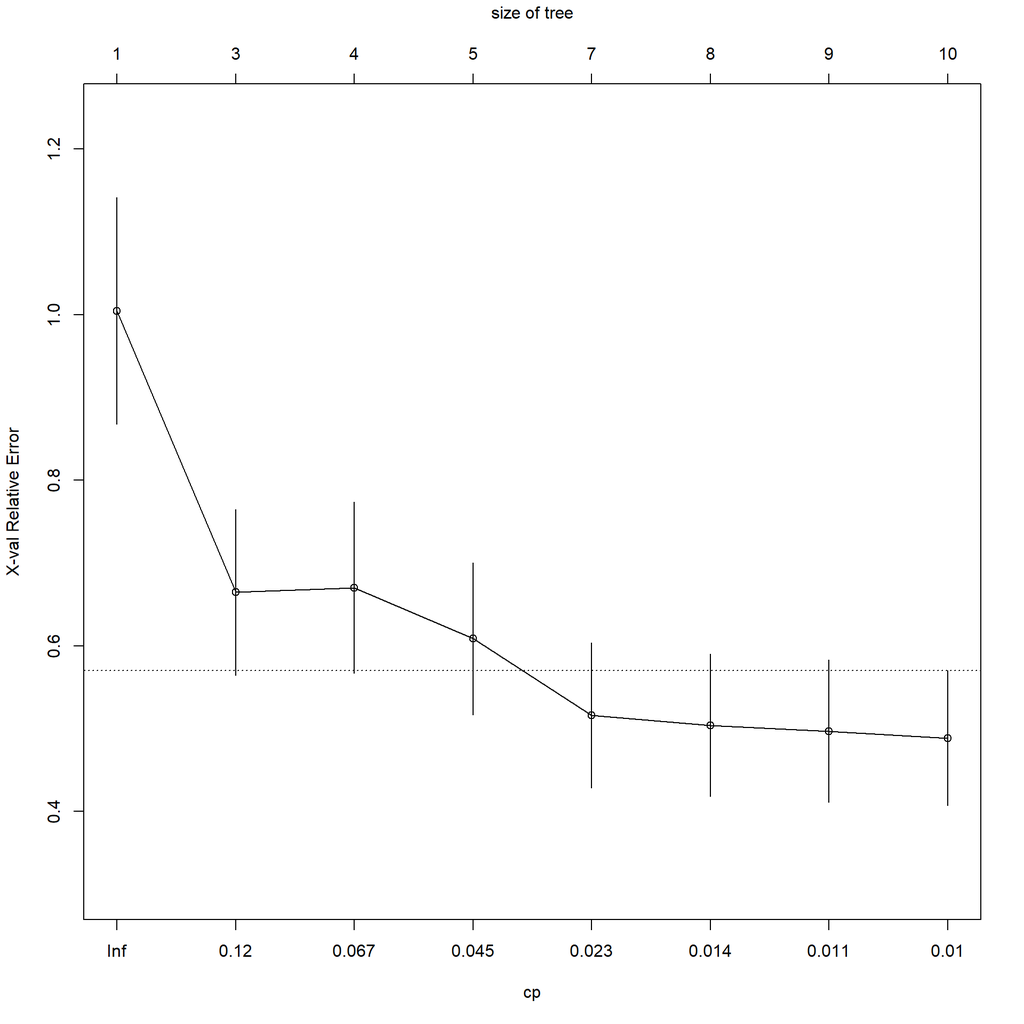

```r
ct_cr <- rpart(TempSens ~ log_slope + log_cat_elev + log_cat_slope + wtd_north_per +
                      wtd_slope_MEAN + log_area + dist_coast_km + asrt_wet +
                      asrt_glac + asrt_lake + snow_ind + summer_precip,
                    data = mod_dat %>% filter(Region == "Copper_River"), method = "anova")
 plotcp(ct_cr)
```

```r
 printcp(ct_cr)
```

```
##
## Regression tree:
## rpart(formula = TempSens ~ log_slope + log_cat_elev + log_cat_slope +
##     wtd_north_per + wtd_slope_MEAN + log_area + dist_coast_km +
##     asrt_wet + asrt_glac + asrt_lake + snow_ind + summer_precip,
##     data = mod_dat %>% filter(Region == "Copper_River"), method = "anova")
##
## Variables actually used in tree construction:
## [1] asrt_lake     dist_coast_km log_cat_slope log_slope     summer_precip
## [6] wtd_north_per
##
## Root node error: 3.5239/156 = 0.022589
##
## n= 156
##
##         CP nsplit rel error  xerror     xstd
## 1 0.199510      0   1.00000 1.00446 0.136996
## 2 0.068681      2   0.60098 0.66462 0.100177
## 3 0.065404      3   0.53230 0.67029 0.103157
## 4 0.030690      4   0.46689 0.60861 0.091766
## 5 0.016967      6   0.40551 0.51604 0.087475
## 6 0.011897      7   0.38855 0.50402 0.085776
## 7 0.010826      8   0.37665 0.49695 0.085818
## 8 0.010000      9   0.36582 0.48860 0.081740
```

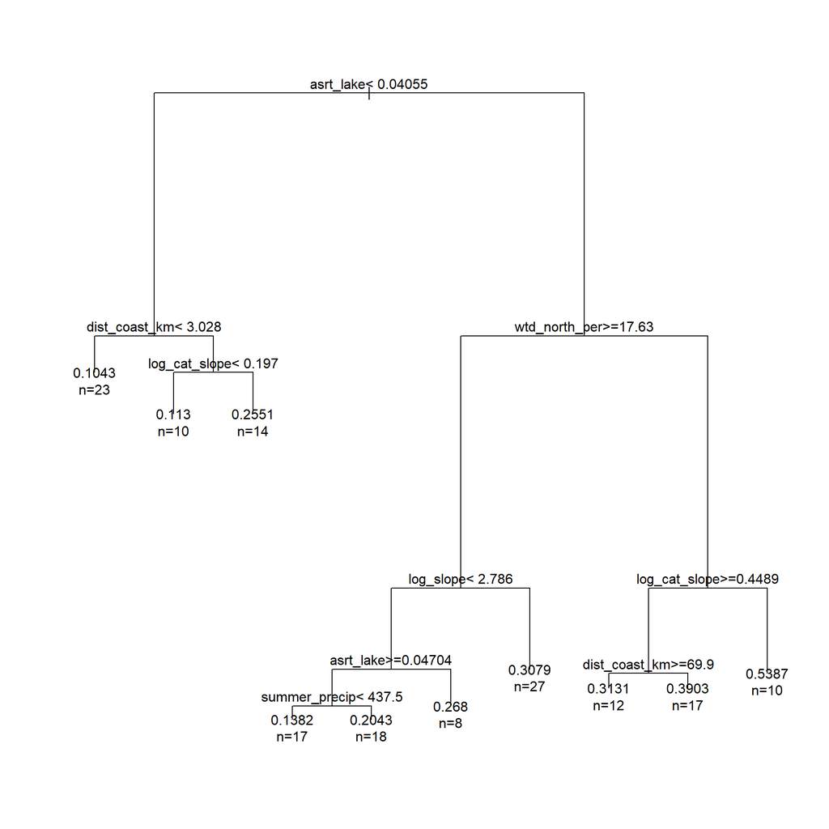

```r
cp_parm <- 0.010826
ct_crpr <- prune(ct_cr, cp = cp_parm)

par(xpd = TRUE)
plot(ct_crpr, compress = TRUE)
text(ct_crpr, use.n = TRUE)
```

```r
summary(ct_crpr)
```

```
## Call:
## rpart(formula = TempSens ~ log_slope + log_cat_elev + log_cat_slope +
##     wtd_north_per + wtd_slope_MEAN + log_area + dist_coast_km +
##     asrt_wet + asrt_glac + asrt_lake + snow_ind + summer_precip,
##     data = mod_dat %>% filter(Region == "Copper_River"), method = "anova")
##   n= 156
##
##           CP nsplit rel error    xerror       xstd
## 1 0.19951033      0 1.0000000 1.0044577 0.13699644
## 2 0.06868147      2 0.6009793 0.6646170 0.10017748
## 3 0.06540415      3 0.5322979 0.6702851 0.10315663
## 4 0.03069013      4 0.4668937 0.6086092 0.09176620
## 5 0.01696685      6 0.4055135 0.5160442 0.08747526
## 6 0.01189721      7 0.3885466 0.5040197 0.08577642
## 7 0.01082611      8 0.3766494 0.4969499 0.08581776
## 8 0.01000000      9 0.3658233 0.4885956 0.08174039
##
## Variable importance
##  wtd_north_per      asrt_lake       log_area wtd_slope_MEAN  log_cat_slope
##             22             14             11             11             10
##       asrt_wet   log_cat_elev      log_slope       snow_ind  dist_coast_km
##              8              7              5              4              4
##  summer_precip      asrt_glac
##              3              2
##
## Node number 1: 156 observations,    complexity param=0.1995103
##   mean=0.2523254, MSE=0.02258917
##   left son=2 (47 obs) right son=3 (109 obs)
##   Primary splits:
##       asrt_lake      < 0.04054766 to the left,  improve=0.1957602, (0 missing)
##       wtd_slope_MEAN < 9.456658   to the left,  improve=0.1941931, (0 missing)
##       log_slope      < 2.547967   to the right, improve=0.1746716, (0 missing)
##       log_cat_elev   < 1.113724   to the right, improve=0.1273075, (0 missing)
##       asrt_wet       < 0.1681871  to the left,  improve=0.1252362, (0 missing)
##   Surrogate splits:
##       wtd_slope_MEAN < 3.642079   to the left,  agree=0.827, adj=0.426, (0 split)
##       wtd_north_per  < 15.96833   to the left,  agree=0.821, adj=0.404, (0 split)
##       log_area       < 0.2641206  to the left,  agree=0.801, adj=0.340, (0 split)
##       asrt_wet       < 0.05108343 to the left,  agree=0.795, adj=0.319, (0 split)
##       log_cat_slope  < 0.918896   to the right, agree=0.782, adj=0.277, (0 split)
```

[output cut: 140 more lines]

```
##
## Node number 25: 8 observations
##   mean=0.2680108, MSE=0.007880917
##
## Node number 28: 12 observations
##   mean=0.3130802, MSE=0.0103692
##
## Node number 29: 17 observations
##   mean=0.3902805, MSE=0.004686358
##
## Node number 48: 17 observations
##   mean=0.1382157, MSE=0.002794271
##
## Node number 49: 18 observations
##   mean=0.2042732, MSE=0.003802487
```

# 3 Prediction scenarios

Spatial domain: salmon habitat for all regions. Select HU12 that intersect anadromous waters catalog. Spatial scale: suggest using stream outlets associated with HU12 boundaries (smallest are 25 km<sup>2</sup>). We can use these outlets to create watersheds and calculate all the same covariates for prediction.

Temporal scenarios: Ideas for our scenarios include picking years within our temporal domain (2001-2019) that represent contrasting conditions that affect TS (e.g. low and high snow years). One problem with this idea is that conditions could vary across our study area so a high snow year in Bristol Bay may not match Copper. Alternatively, we could develop scenarios for prediction using high and low ranges of snowpack or precipitation for each region.

Comparison of standardized (subtract mean and divide by sd) temperature and precipitation values by different regions:

- 2019 warm and low precipitation
- 2016 warm and high precipitation
- 2006 cold and high precipitation
- 2017 and 2009 about normal years for both

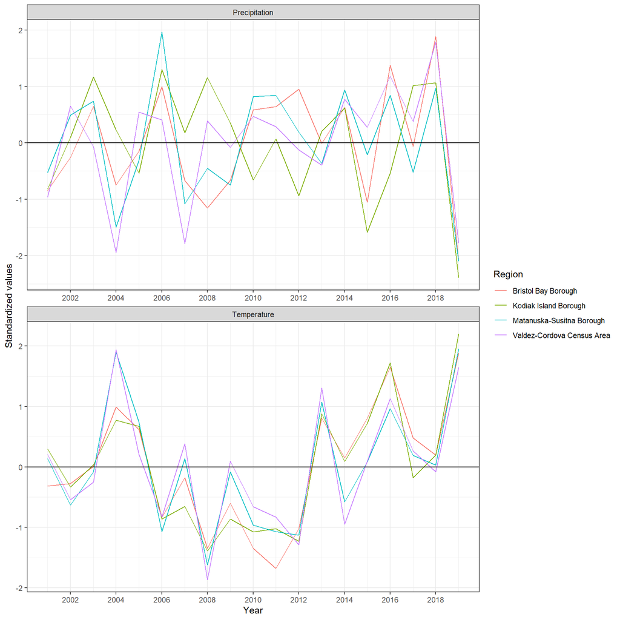

```r
clim_dat <- readRDS("output/clim_dat.rds")

scale_var <- function(x){
  (x - mean(x, na.rm=TRUE)) / sd(x, na.rm=TRUE)
}

#deviations from normal
clim_dat %>%
  group_by(Region, parameter) %>%
  dplyr::mutate(Value_metric_sc = scale_var(Value_metric)) %>%
  ggplot(aes(x = Year, y = Value_metric_sc, color = Region)) +
  geom_line() +
  scale_x_continuous(breaks = c(seq(2000, 2019, 2))) +
  facet_wrap(~parameter, scales = "free", ncol = 1) +
  geom_hline(aes(yintercept = 0)) +
  theme_bw() +
  theme(legend.position = "right") +
  labs(y = "Standardized values")
```

Snowtel data indicate April 1st SWE (magnitude of spring snowpack) for different sites across some of our regions. Note that there were no snowtel sites with data for Bristol Bay or Kodiak. From Tim’s paper, 2012 and 2013 were high snow years and 2015 was a low snow year.

- 2012 was a high snow year
- 2015 was a low snow year

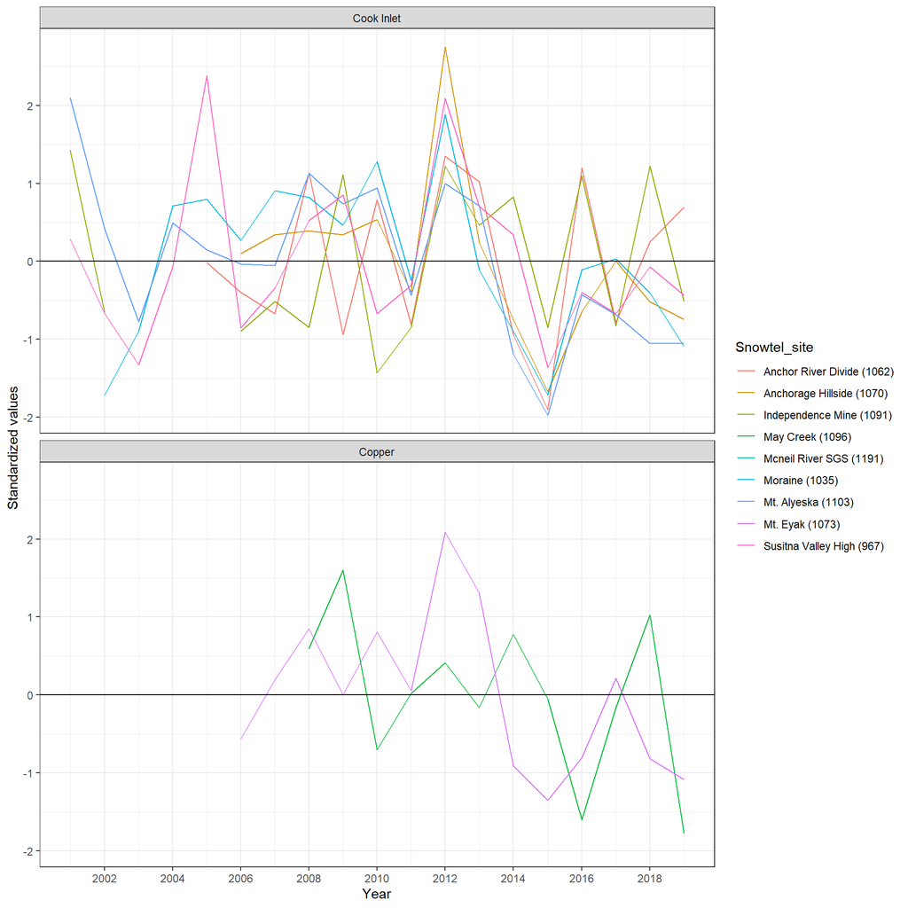

```r
snowtel <- readRDS("output/snowtel.rds")

#deviations from normal
snowtel %>%
  filter(!grepl("Gulk|Tela", Snowtel_site)) %>%
  group_by(Snowtel_site) %>%
  mutate(swe_sc = scale_var(Apr1_SWE)) %>%
  ggplot(aes(x = Year, y = swe_sc, color = Snowtel_site)) +
  geom_line() +
  scale_x_continuous(breaks = c(seq(2000, 2019, 2))) +
  theme_bw() +
  theme(legend.position = "right") +
  geom_hline(aes(yintercept = 0)) +
  facet_wrap(~Region, ncol = 1) +
  labs(y = "Standardized values")
```